# Simple Linear Regression

```r
# Load your libraries
library(car)
library(DT)
library(tidyverse)
library(pander)
library(mosaic)

# Load your data after saving a csv file in your Data folder.
# You can use either
tacoma <- read.csv("../../Data/tacoma100rexy.csv", header=TRUE)
# or
#   library(readr)
#   someName <- read_csv("../Data/YourDataFileName.csv")

# Don't forget to run "Session -> Set Working Directory -> To Source file location"
View(tacoma)
```

## Background

I have gotten into the habit of scrolling facebook marketplace always looking for vehicles of all sorts hoping to find a deal. But how to we determine whats a good deal? There are numerous factors that we are not going to get into during the process of this analysis. One of the aspects I was curious about is how does the mileage affect the price? If we can find out how the price is affected by mileage we can potentially determine what a good price would be for a certain vehicle. For this data set we have narrowed our scope down to Toyota Tacomas within 100 miles of Rexburg ,ID that are posted for sale on facebook. In our data we have a relatively small amount of data points at 19.

### Show Data

The data for this analysis comes from facebook.

#### Original Data

```r
datatable(tacoma, options=list(lengthMenu = c(3,10,30),scrollY=300,scroller=TRUE,scrollX=TRUE),
            extensions="Scroller")
```

|  | Year | Mileage | Price | City | State |
| --- | --- | --- | --- | --- | --- |
| 1 | 1995 | 280000 | 7300 | Alpine | WY |
| 2 | 2010 | 111000 | 4000 | St Anthony | ID |
| 3 | 1999 | 120000 | 15000 | Pocatello | ID |
| 4 | 1996 | 270000 | 3500 | Grace | ID |
| 5 | 2016 | 63000 | 33500 | Afton | WY |
| 6 | 2015 | 118000 | 30000 | Virginia City | MT |
| 7 | 1995 | 400000 | 1600 | American Falls | ID |
| 8 | 2004 | 150000 | 10500 | Idaho Falls | ID |
| 9 | 2019 | 31000 | 34770 | Idaho Falls | ID |
| 10 | 2008 | 190000 | 9000 | Wilson | WY |

[output cut: 9 more lines]

## Analysis

This analysis attempts to model the mileage of Tacomas in relation to their price using a linear regression. Specifically,

$$\underbrace{Y_i}_\text{Price} = \beta_0 + \beta_1
\underbrace{X_i}_\text{Mileage} + \epsilon_i \quad \text{where} \
\epsilon_i \sim N(0, \sigma^2)$$

The hypotheses for our study concern the slope of the regression model, $\beta_1$. If the slope is zero, then there is not a meaningful relationship between the mileage and the price of Toyota Tacomas.

$$H_0: \beta_1 = 0$$
$$H_a: \beta_1 \neq 0$$
$$\alpha = 0.05$$

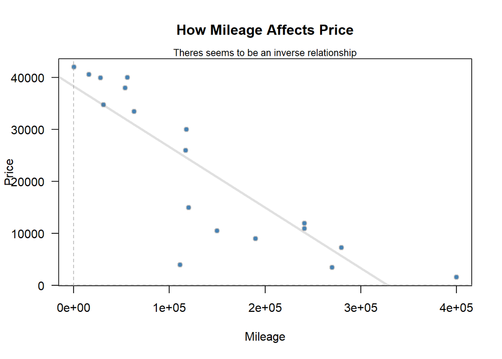

```r
plot(Price ~ Mileage, data=tacoma, pch=21, bg="steelblue", col="gray",
     xlab="Mileage", ylab="Price",
     main="How Mileage Affects Price", las=1)
mtext(side=3, text="Theres seems to be an inverse relationship", cex=0.8)
tacoma.lm <- lm(Price ~ Mileage, data=tacoma)
abline(tacoma.lm, lwd=3, col=rgb(.4,.4,.4,.2))
abline(v=seq(40,120,20), h=seq(40,120,20), lty=2, col=rgb(.6,.6,.6,.2))
```

```r
# This code run in Console to obtain the correlation
#tacoma %>% summarise(cor(Price, Mileage, use="complete.obs"))
```

The equation of the estimated regression equation from the scatterplot above is given by

$$\underbrace{\hat{Y}_i}_\text{Price} = 38336 - 0.1166
\underbrace{X_i}_\text{Mileage}$$

The estimated slope of this regression is -0.1166, which is significantly different from zero $(p = 1.934e-06)$. Follows is a complete table showing the summary of the full regression results.

```r
pander(summary(tacoma.lm))
```

|  | Estimate | Std. Error | t value | Pr(>\|t\|) |
| --- | --- | --- | --- | --- |
| **(Intercept)** | 38336 | 2961 | 12.95 | 3.127e-10 |
| **Mileage** | -0.1166 | 0.01652 | -7.055 | 1.934e-06 |

| Observations | Residual Std. Error | $R^2$ | Adjusted $R^2$ |
| --- | --- | --- | --- |
| 19 | 7732 | 0.7454 | 0.7304 |

Table: Fitting linear model: Price ~ Mileage

For the interested reader, notice the that value of $R^2$ is the square of the correlation of the scatterplot. It shows that 74.54% of the variation Price measured.

## Interpretation

The estimated value of the slope is -0.1166 which shows that on average, each mile accumulated decreases the price by 0.1166 from a baseline of 38,336. This shows that mileage of a Toyota Tacoma can make a significant impact on the price of such.

## Appropriateness of the above Regression

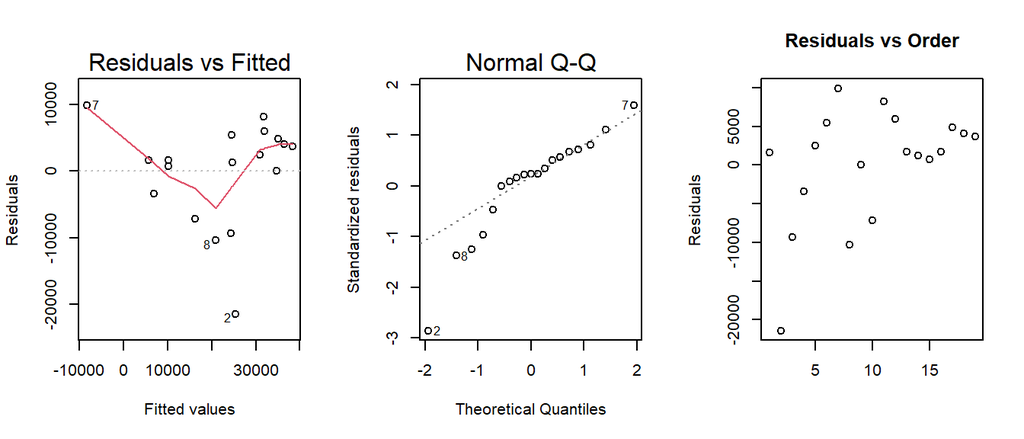

````r
# Note that this r-chunk uses ```{r, fig.height=3}
# to reduce the size of the plots. This makes the plots
# look a little nicer and also emphasizes that they are not
# as important as the main graphic (scatterplot) of the analysis.

par(mfrow=c(1,3))
plot(tacoma.lm, which=1:2)
plot(tacoma.lm$residuals, main="Residuals vs Order", xlab="",
     ylab="Residuals")
````